# Lab1_inR_NEllermeier

#Biostat 705 Lab 1 #Kenya Datset #Nathan Ellermeier #Nine Eleven

#libraries

```r
library(haven)
library(skimr)
library(tidyverse)
```

```r
library(ggplot2)
```

#pull in dataset

```r
kenya_dataset <- read_dta("data/lab_1_kenya.dta")
```

#explore dataset

```r
head(kenya_dataset)
```

| caseid | v008 | v011 | v025 | v437 | v438 | v463z | bord | b3 | b4 | b5 | b7 | m2n | m18 | m19 | s109 | mage | magec |
| --- | --- | --- | --- | --- | --- | --- | --- | --- | --- | --- | --- | --- | --- | --- | --- | --- | --- |
| 56 17 2 | 1310 | 902 | 2 | 473 | 1599 | 1 | 1 | 1108 | 2 | 1 | NA | NA | NA | NA | 1 | 17 | 0 |
| 238 70 2 | 1308 | 1020 | 2 | 508 | 1626 | 1 | 2 | 1226 | 2 | 1 | NA | NA | NA | NA | 1 | 17 | 0 |
| 215 1 1 | 1309 | 835 | 1 | 505 | 1581 | 1 | 1 | 1000 | 2 | 0 | 0 | NA | NA | NA | 0 | 13 | 0 |
| 89185 1 | 1309 | 824 | 2 | 733 | 1704 | 1 | 1 | 1025 | 2 | 1 | NA | NA | NA | NA | 1 | 16 | 0 |
| 76 95 2 | 1307 | 1030 | 1 | 668 | 1702 | 1 | 1 | 1228 | 1 | 0 | 0 | NA | NA | NA | 1 | 16 | 0 |
| 34177 5 | 1308 | 1049 | 1 | 705 | 1522 | 1 | 1 | 1260 | 1 | 1 | NA | 0 | 3 | 9996 | 1 | 17 | 0 |

```r
skim(kenya_dataset)
```

Data summary

| Name | kenya_dataset |
| --- | --- |
| Number of rows | 22534 |
| Number of columns | 18 |
| _______________________ |  |
| Column type frequency: |  |
| character | 10 |
| numeric | 8 |
| ________________________ |  |
| Group variables | None |

**Variable type: character**

| skim_variable | n_missing | complete_rate | min | max | empty | n_unique | whitespace |
| --- | --- | --- | --- | --- | --- | --- | --- |
| caseid | 0 | 1.00 | 15 | 15 | 0 | 6102 | 0 |
| v025 | 0 | 1.00 | 1 | 1 | 0 | 2 | 0 |
| v463z | 0 | 1.00 | 1 | 1 | 0 | 3 | 0 |
| b4 | 0 | 1.00 | 1 | 1 | 0 | 2 | 0 |
| b5 | 0 | 1.00 | 1 | 1 | 0 | 2 | 0 |
| m2n | 18452 | 0.18 | 1 | 1 | 0 | 3 | 0 |
| m18 | 16455 | 0.27 | 1 | 1 | 0 | 7 | 0 |
| m19 | 16455 | 0.27 | 3 | 4 | 0 | 127 | 0 |
| s109 | 0 | 1.00 | 1 | 1 | 0 | 6 | 0 |
| magec | 0 | 1.00 | 1 | 1 | 0 | 3 | 0 |

**Variable type: numeric**

| skim_variable | n_missing | complete_rate | mean | sd | p0 | p25 | p50 | p75 | p100 | hist |
| --- | --- | --- | --- | --- | --- | --- | --- | --- | --- | --- |
| v008 | 0 | 1.00 | 1308.62 | 1.11 | 1307 | 1308 | 1309 | 1310 | 1311 | ▆▆▇▇▁ |
| v011 | 0 | 1.00 | 880.90 | 98.95 | 708 | 799 | 880 | 960 | 1129 | ▇▇▇▆▂ |
| v437 | 275 | 0.99 | 586.53 | 123.68 | 321 | 500 | 563 | 650 | 1594 | ▇▆▁▁▁ |
| v438 | 308 | 0.99 | 1591.97 | 76.33 | 1010 | 1551 | 1593 | 1635 | 2065 | ▁▁▇▂▁ |
| bord | 0 | 1.00 | 3.14 | 2.16 | 1 | 1 | 3 | 4 | 15 | ▇▃▁▁▁ |
| b3 | 0 | 1.00 | 1176.96 | 92.30 | 860 | 1113 | 1193 | 1254 | 1310 | ▁▂▃▆▇ |
| b7 | 20329 | 0.10 | 22.64 | 49.33 | 0 | 0 | 6 | 22 | 396 | ▇▁▁▁▁ |
| mage | 0 | 1.00 | 24.23 | 6.16 | 11 | 20 | 23 | 28 | 48 | ▃▇▅▂▁ |

#creating new variable bord5 – should we be creating these values as strings or numeric? #if dichtomous, how to make dichotomous? in R, is that just a string of 0/1?

```r
kenya <- kenya_dataset %>%
  mutate(bord5 = NA)

kenya <- kenya %>%
  mutate(bord5 = case_when(
    bord <5 ~ "0",
    bord >=5 ~ "1",
  TRUE~NA_character_
  ))
```

```r
skim(kenya$bord5)
```

Data summary

| Name | kenya$bord5 |
| --- | --- |
| Number of rows | 22534 |
| Number of columns | 1 |
| _______________________ |  |
| Column type frequency: |  |
| character | 1 |
| ________________________ |  |
| Group variables | None |

**Variable type: character**

| skim_variable | n_missing | complete_rate | min | max | empty | n_unique | whitespace |
| --- | --- | --- | --- | --- | --- | --- | --- |
| data | 0 | 1 | 1 | 1 | 0 | 2 | 0 |

```r
table(kenya$bord5)
```

```
##
##     0     1
## 17400  5134
```

#investigate b4

```r
skim(kenya$b4)
```

Data summary

| Name | kenya$b4 |
| --- | --- |
| Number of rows | 22534 |
| Number of columns | 1 |
| _______________________ |  |
| Column type frequency: |  |
| character | 1 |
| ________________________ |  |
| Group variables | None |

**Variable type: character**

| skim_variable | n_missing | complete_rate | min | max | empty | n_unique | whitespace |
| --- | --- | --- | --- | --- | --- | --- | --- |
| data | 0 | 1 | 1 | 1 | 0 | 2 | 0 |

#generate male variable #in original dataset, b4 is coded as 2 = woman and 1 = man #NEED TO LABEL VARIABLES

```r
kenya <- kenya %>%
  mutate(male = NA)

kenya <- kenya %>%
  mutate(male = case_when(
    b4 ==2 ~ "0",
    b4 ==1 ~ "1",
  TRUE~NA_character_
  ))
```

#generating male2 using if_else command #just for fun w/ if_else() command

```r
kenya <- kenya %>%
  mutate(male2 = if_else(b4 ==2, "0", "1"))
```

#variable labels #fucking finally #but all this did is created a vector and replaced my values with strings female and male ????

```r
kenya$male2 <- factor(kenya$male2,
                levels = c(0,1),
                labels = c("Female","Male"))
```

#generate new variable mweight

```r
kenya <- kenya %>%
  mutate(mweight = v437/10)
```

#generate new variable mheight

```r
kenya <- kenya %>%
  mutate(mheight = v438/1000)
```

#generate new variable mbmi

```r
kenya <- kenya %>%
  mutate(mbmi = mweight / mheight)
```

```r
skim(kenya$mheight)
```

Data summary

| Name | kenya$mheight |
| --- | --- |
| Number of rows | 22534 |
| Number of columns | 1 |
| _______________________ |  |
| Column type frequency: |  |
| numeric | 1 |
| ________________________ |  |
| Group variables | None |

**Variable type: numeric**

| skim_variable | n_missing | complete_rate | mean | sd | p0 | p25 | p50 | p75 | p100 | hist |
| --- | --- | --- | --- | --- | --- | --- | --- | --- | --- | --- |
| data | 308 | 0.99 | 1.59 | 0.08 | 1.01 | 1.55 | 1.59 | 1.64 | 2.06 | ▁▁▇▂▁ |

#now time to consider how we might save the following histograms so that it’s easy for Larry #Mother’s Weight

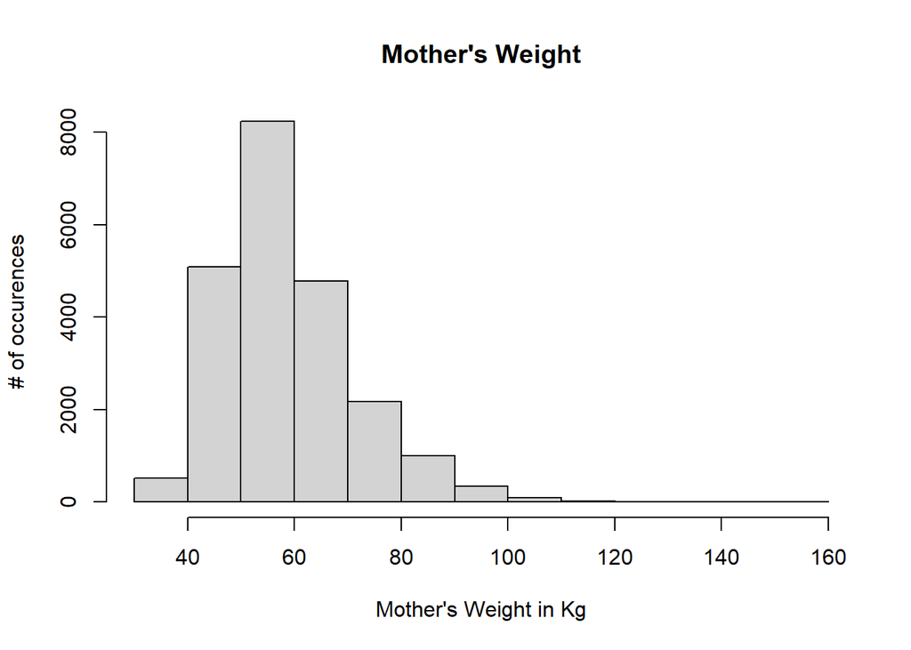

```r
hist(kenya$mweight, main = "Mother's Weight" , xlab = "Mother's Weight in Kg", ylab = "# of occurences")
```

#I really wanna do some ggplot #Mother’s Height

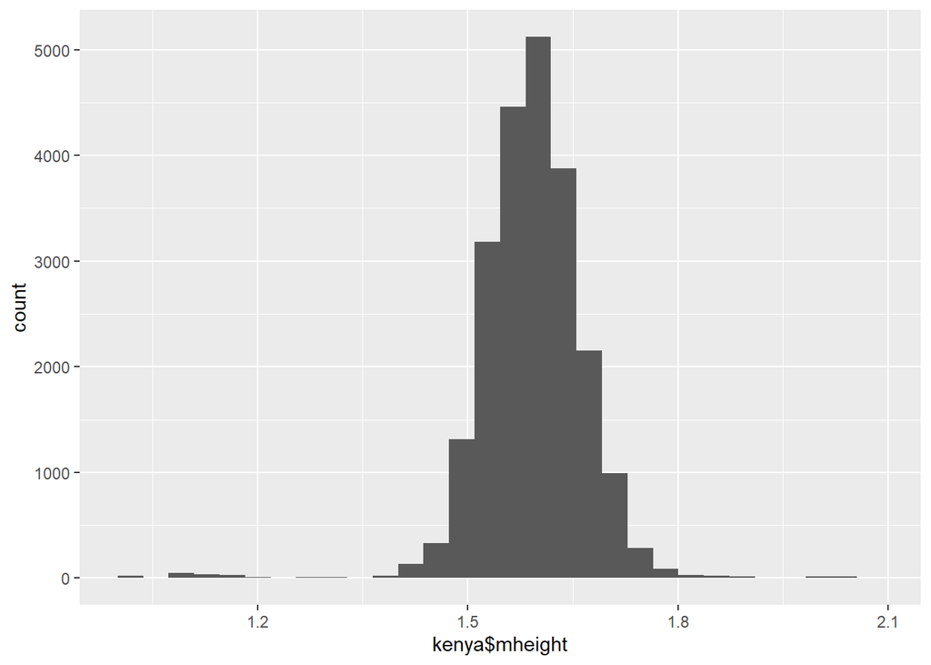

```r
ggplot(data = kenya, aes(kenya$mheight)) +
         geom_histogram()
```

#different code for histogram using ggplot

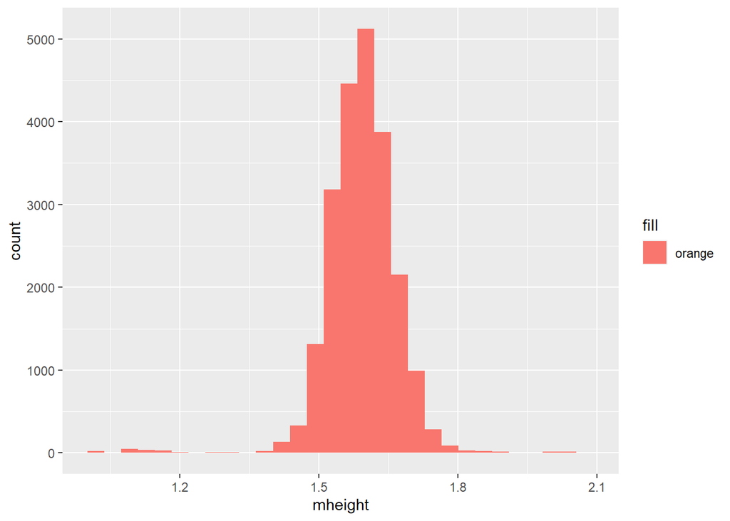

```r
kenya %>%
  ggplot() +
  geom_histogram(aes(mheight,fill = "orange"))
```

#and compare it to base R hist()

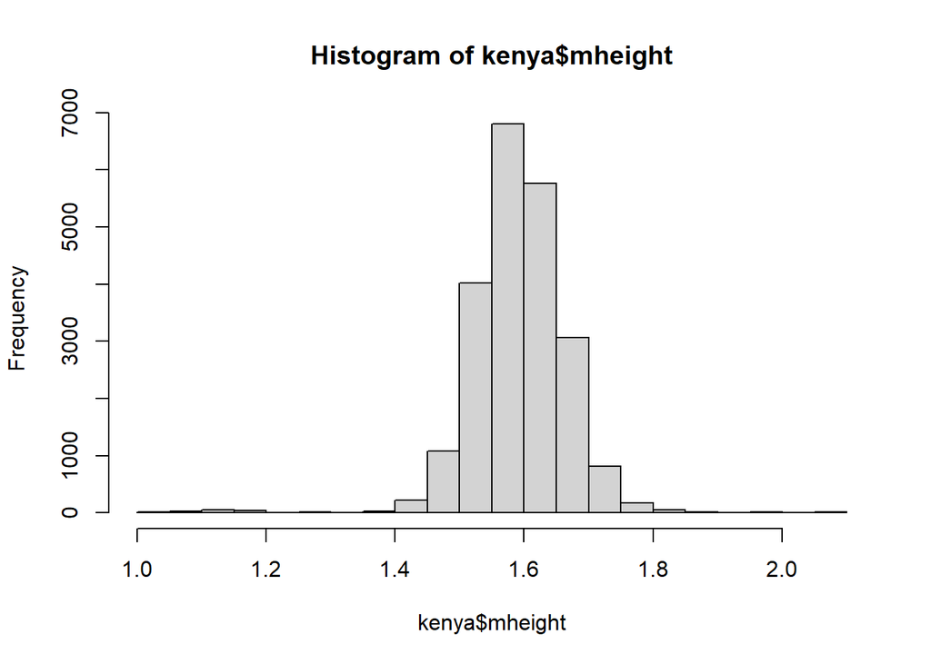

```r
hist(kenya$mheight)
```

#qplot w/ mheight

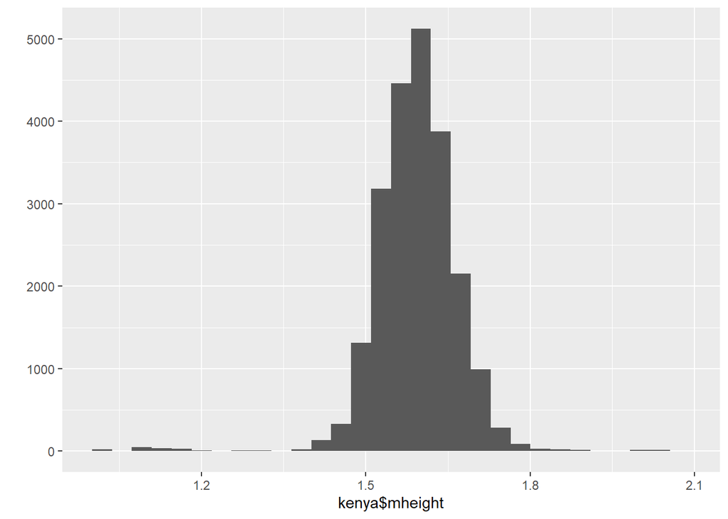

```r
qplot(kenya$mheight, geom="histogram")
```

#qplot w/ adjustments #argument for bindwidth either doesn’t show perceivable change or give you a giant blue box over whole visualization– wtf #difference b/w I() and !I() in fill = and col = – without it, the qplot() function prints a legend saying that “col=”red"" #xlim = adjust the limit of the x axis with vector running between c(a,b) #binwidth function does not seem to change binwidth!!

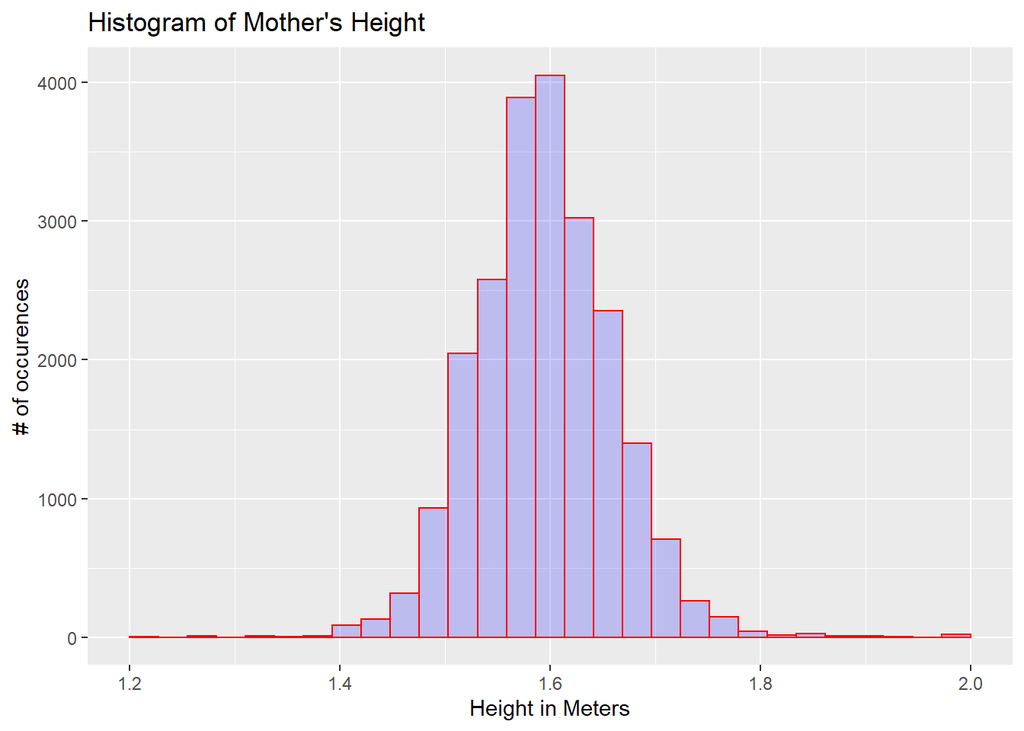

```r
qplot(kenya$mheight,
      geom="histogram",
      bindwidth=.001,
      main = "Histogram of Mother's Height",
      xlab = "Height in Meters",
      ylab = "# of occurences",
      fill =I("blue"),
      col=I("red"),
      alpha=I(.2),
      xlim = c(1.2, 2)
      )
```

#ggplot w/ mheight #ADDING #why is this showing up differently for # of occurences than the histogram above? #breaks() are used for binwidth. can also express the seq() argument using c(a,b) instead of seq(a,b, by=c)

#result renders “removed 308 rows containing non-finite values(stat_bin)” #and also “removed 191 rows containing missing values (geom_bar)” #what is the distinction here– does data need cleaning for non-finite values? how to do that–

#aes(fill=..count..) renders a hist with darker colors for few fills and ligther colors for more fills

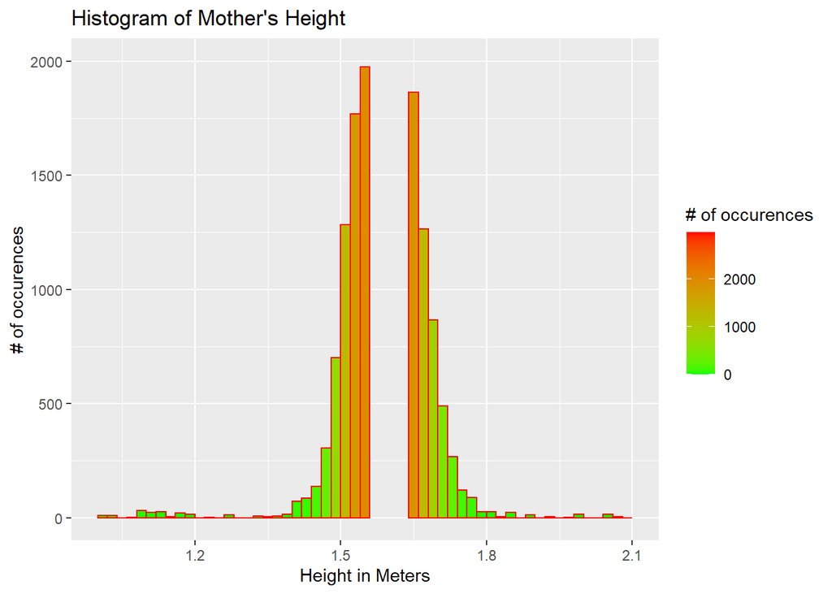

```r
ggplot(data=kenya, aes(x=mheight)) +
  geom_histogram(breaks=seq(0, 3, by=.02),
                 col="red",
                 aes(fill=..count..),
                 alpha = 1) +
  scale_fill_gradient("# of occurences", low="green", high="red") +
  labs(title="Histogram of Mother's Height", x="Height in Meters", y="# of occurences") +
  xlim(c(1,2.1)) +
  ylim(c(0,2000))
```

#create histogram

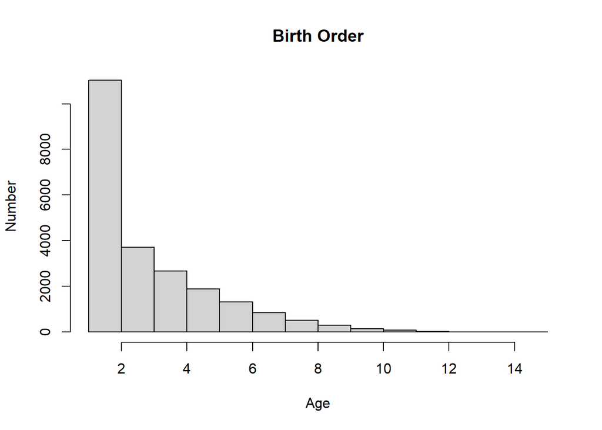

```r
hist(kenya$bord , main = "Birth Order", xlab = "Age", ylab = "Number")
```